# Statistics on biomedical data

Katleen De Preter & Celine Everaert

10/23/2023

# 1 Introduction

Welcome in the practical session on the use of R for statistical analysis.

In this R lesson, you will learn to apply and interpret some statistical tests.

Before starting, I would like to refresh some important remarks on programming.

1. If you don’t know how to use a specific function, read the help files of the function and try the example code found in last paragraph of the help information. You can call these files by using *?namefunction* or *help(namefunction)*.
2. When a script is not working, read the error messages! Often it explains itself. Mostly warning messages can be ignored.
3. Don’t be afraid to Google your questions or error messages!
4. Analyse the question before you start to program. Split a complex problem in different parts. Try to answer the following questions: What is the hypothesis? Which test do you need to use? Which data is needed to perform this test? Do you have this data or how do you get the data you need? What is the answer on the question?
5. Dare to change scripts/commands and look what the effect is! Play with R! Don’t be afraid, in the worst case you need to restart RStudio. Your computer will definitly not explode!
6. Be aware that there are different scripting options for the same question.

Enjoy!

## 1.1 Load the package tidyverse

```r
library(tidyverse)
```

## 1.2 A dataset for the exercises of today

In this lesson you will (re)analyse expression data of a published study (Vermeulen et al., Lancet Oncology, 2009) (http://www.thelancet.com/journals/lanonc/article/PIIS1470-2045(09)70154-8/fulltext). We used this data before to make heatmaps. In this study we selected 59 genes with prognostic potential in neuroblastoma cases, i.e. the expression of these genes is correlated with survival outcome of neuroblastoma patients. The expression of these genes was measured using quantitative PCR in 364 neuroblastoma tumors for which we have clinical data. The file named qPCR_expression_data.tsv contains qPCR expression data of 59 genes in 364 neuroblastoma tumors. The second file named qPCR_sample_data.tsv contains some clinical data of the 364 samples:

```
MNA = presence of amplification of oncogene MYCN (0=not present, 1=MYCN-amp present),

Stage = tumor stage (1, 2, 3, 4 or 5=4S),

event = have an event or not (0=no, 1=yes),

survival = did the patient die of disease or not (0=no, 1=yes),

EFS = event free survival time (time from diagnosis until event or follow-up) ("EFS" linked to "event"),

OS = overall survival time (time from diagnosis til dead or follow-up) ("OS" linked to "survival").
```

Save the 2 tsv files from Ufora into your working directory first. Then you can check which files are in your working directory and whether these 2 new files are also present!

```r
dir()
```

```
## [1] "gene_expression.txt"          "qPCR_expression_data.tsv"
## [3] "qPCR_sample_data.tsv"         "Statistics_SOLVED_2023.html"
## [5] "Statistics_SOLVED_2023.Rmd"   "Statistics_UNSOLVED_2023.Rmd"
```

During the previous lessons you have learned how to read data from a tsv file into your R-environment. Use the appropriate readR function (*read_tsv()*, *read_csv()*, …). Do you need to change some of the datatypes, eg to factors? You might used the base way *read.table()*, but than you need to tweak more parameters.

```r
expression_data <- read_tsv(file = "qPCR_expression_data.tsv")
sample_data <- read_tsv(file = "qPCR_sample_data.tsv", col_types = "cfcffdd", col_names = TRUE)
```

Hopefully, you didn’t forget to assign the imported data to an object with a self chosen name? If not, you have only printed the imported data in your console. It is important that you import and store the data as an object, so that you can use it in R. Choose a good name, for example expression_data and sample_data, …

Now apply the head and tail function to your imported data. You will see that the top and last 6 lines of your data are printed in the console. In this way you can check whether your data are imported correctly, and you can see how the data look like.

```r
# expression data
head(expression_data)
```

```
## # A tibble: 6 × 365
##   genename     A1     A10    A11     A12     A13    A14    A15    A16    A17
##   <chr>     <dbl>   <dbl>  <dbl>   <dbl>   <dbl>  <dbl>  <dbl>  <dbl>  <dbl>
## 1 gene8    -0.669  2.42   -1.07   0.883  -1.72   -0.502 -3.32   1.15  -0.477
## 2 gene9     0.424  3.07   -4.45   0.0662 -1.53    1.79   0.376  2.06  -2.87
## 3 gene10   -0.500  0.0722  0.220  3.41    1.07   -0.773  3.96  -0.828  0.122
## 4 gene11    0.308  3.53    1.64  -1.96   -0.0491  1.96  -1.35   0.301  1.23
## 5 gene12    1.50   1.14    0.832  0.0641  0.854   1.84   0.354  3.93  -2.19
## 6 gene13    0.440 -4.11   -0.670  0.812  -0.998  -0.913 -1.56  -0.718  0.922
## # ℹ 355 more variables: A18 <dbl>, A19 <dbl>, A2 <dbl>, A20 <dbl>, A21 <dbl>,
## #   A22 <dbl>, A23 <dbl>, A24 <dbl>, A3 <dbl>, A4 <dbl>, A5 <dbl>, A6 <dbl>,
## #   A7 <dbl>, A8 <dbl>, A9 <dbl>, B1 <dbl>, B10 <dbl>, B11 <dbl>, B12 <dbl>,
## #   B13 <dbl>, B14 <dbl>, B15 <dbl>, B16 <dbl>, B17 <dbl>, B18 <dbl>,
## #   B19 <dbl>, B2 <dbl>, B20 <dbl>, B21 <dbl>, B22 <dbl>, B23 <dbl>, B24 <dbl>,
## #   B3 <dbl>, B4 <dbl>, B5 <dbl>, B6 <dbl>, B7 <dbl>, B8 <dbl>, B9 <dbl>,
## #   C1 <dbl>, C10 <dbl>, C11 <dbl>, C12 <dbl>, C13 <dbl>, C14 <dbl>, …
```

```r
tail(expression_data)
```

```
## # A tibble: 6 × 365
##   genename     A1    A10    A11    A12    A13      A14   A15    A16    A17
##   <chr>     <dbl>  <dbl>  <dbl>  <dbl>  <dbl>    <dbl> <dbl>  <dbl>  <dbl>
## 1 gene64   -0.473  2.10  -0.323  0.589 -2.22  -0.446   -3.24 0.199  -0.961
## 2 gene65    0.412 -0.935  1.59  -0.655  0.325 -1.31    -1.13 1.15    0.585
## 3 gene66    1.44  -5.05   0.295 -2.31   1.43  -0.168    1.03 0.747  -2.25
## 4 gene67    2.68   2.46   2.63   0.988  1.92   0.00293  2.39 0.0779  1.88
## 5 gene68   -0.751 -0.228 -2.57   0.732 -3.74  -0.663   -2.02 1.12    0.102
## 6 gene69    0.965 -1.14  -0.235  2.25   0.578 -1.70     1.50 1.38   -1.30
## # ℹ 355 more variables: A18 <dbl>, A19 <dbl>, A2 <dbl>, A20 <dbl>, A21 <dbl>,
## #   A22 <dbl>, A23 <dbl>, A24 <dbl>, A3 <dbl>, A4 <dbl>, A5 <dbl>, A6 <dbl>,
## #   A7 <dbl>, A8 <dbl>, A9 <dbl>, B1 <dbl>, B10 <dbl>, B11 <dbl>, B12 <dbl>,
## #   B13 <dbl>, B14 <dbl>, B15 <dbl>, B16 <dbl>, B17 <dbl>, B18 <dbl>,
## #   B19 <dbl>, B2 <dbl>, B20 <dbl>, B21 <dbl>, B22 <dbl>, B23 <dbl>, B24 <dbl>,
## #   B3 <dbl>, B4 <dbl>, B5 <dbl>, B6 <dbl>, B7 <dbl>, B8 <dbl>, B9 <dbl>,
## #   C1 <dbl>, C10 <dbl>, C11 <dbl>, C12 <dbl>, C13 <dbl>, C14 <dbl>, …
```

```r
# sample data
head(sample_data)
```

```
## # A tibble: 6 × 7
##   patientID MNA   Stage event survival   EFS    OS
##   <chr>     <fct> <chr> <fct> <fct>    <dbl> <dbl>
## 1 A1        0     5     0     0        181.  181.
## 2 A10       1     5     0     0         23.7  23.7
## 3 A11       0     4     1     1         23.6  41.4
## 4 A12       0     3     0     0         36    36
## 5 A13       0     2     0     0        160   160
## 6 A14       0     1     0     0         30.5  30.5
```

```r
tail(sample_data)
```

```
## # A tibble: 6 × 7
##   patientID MNA   Stage event survival   EFS    OS
##   <chr>     <fct> <chr> <fct> <fct>    <dbl> <dbl>
## 1 P21       0     5     0     0         67    67
## 2 P23       0     1     0     0          0.1   0.1
## 3 P3        1     4     0     0         32.1  32.1
## 4 P5        1     4     1     1         21.5  23.9
## 5 P7        1     4     0     0         41.2  41.2
## 6 P9        1     4     0     0         52.3  52.3
```

**VERY IMPORTANT!!!** Sometimes, it is more logical to work with the expression data as matrix, since these are all numerical values. Therefore you can convert the expression_data data.frame/tibble to a matrix with the as.matrix function. Save this in another object. As demonstrated in the last practical session, you can check the converted object with *class()*. Remark that row and column names might disappear and/or the data type might be incorrect (eg. strings instead of numbers).

```r
class(expression_data)
```

```
## [1] "spec_tbl_df" "tbl_df"      "tbl"         "data.frame"
```

```r
expression_data_matrix <- as.matrix(expression_data)
class(expression_data_matrix)
```

```
## [1] "matrix" "array"
```

```r
head(expression_data_matrix)
```

```
##      genename A1             A10             A11           A12
## [1,] "gene8"  " -0.66902109" "  2.423478907" "-1.06902109" "  0.883478907"
## [2,] "gene9"  "  0.42372253" "  3.066222527" "-4.44627747" "  0.066222527"
## [3,] "gene10" " -0.50031593" "  0.072184066" " 0.21968407" "  3.412184066"
## [4,] "gene11" "  0.30844447" "  3.530944472" " 1.63844447" " -1.959055528"
## [5,] "gene12" "  1.50160714" "  1.144107143" " 0.83160714" "  0.064107143"
## [6,] "gene13" "  0.43973924" " -4.107760762" "-0.67026076" "  0.812239238"
##      A13           A14            A15          A16            A17
## [1,] "-1.71652109" "-0.501521093" "-3.3165211" "  1.15347891" "-0.476521093"
## [2,] "-1.53377747" " 1.791222527" " 0.3762225" "  2.05622253" "-2.873777473"
## [3,] " 1.07218407" "-0.772815934" " 3.9621841" " -0.82781593" " 0.122184066"
## [4,] "-0.04905553" " 1.955944472" "-1.3490555" "  0.30094447" " 1.230944472"
## [5,] " 0.85410714" " 1.839107143" " 0.3541071" "  3.93410714" "-2.185892857"
## [6,] "-0.99776076" "-0.912760762" "-1.5577608" " -0.71776076" " 0.922239238"
##      A18            A19           A2             A20            A21
```

[output cut: 503 more lines]

Now look again which objects are saved in the R-environment. Do you remember the *ls()* function?

```r
ls()
```

```
## [1] "expression_data"        "expression_data_matrix" "sample_data"
```

In some cases it might be more interesting to have the expression data transposed (genes as columns, instead of patients). You can perform this with the following code:

```r
expression_data_pergene <- expression_data %>%
    pivot_longer(-genename) %>%
    pivot_wider(names_from = "genename", values_from="value")
expression_data_pergene
```

```
## # A tibble: 364 × 60
##    name   gene8   gene9  gene10  gene11  gene12 gene13 gene14 gene15  gene16
##    <chr>  <dbl>   <dbl>   <dbl>   <dbl>   <dbl>  <dbl>  <dbl>  <dbl>   <dbl>
##  1 A1    -0.669  0.424  -0.500   0.308   1.50    0.440 -2.18   2.34   0.191
##  2 A10    2.42   3.07    0.0722  3.53    1.14   -4.11   0.637  2.24   2.02
##  3 A11   -1.07  -4.45    0.220   1.64    0.832  -0.670  0.595  5.51  -2.36
##  4 A12    0.883  0.0662  3.41   -1.96    0.0641  0.812  1.18   1.70   4.40
##  5 A13   -1.72  -1.53    1.07   -0.0491  0.854  -0.998 -2.43   4.11  -0.146
##  6 A14   -0.502  1.79   -0.773   1.96    1.84   -0.913  1.06   1.53  -0.0813
##  7 A15   -3.32   0.376   3.96   -1.35    0.354  -1.56  -3.09   3.30   0.634
##  8 A16    1.15   2.06   -0.828   0.301   3.93   -0.718  2.43  -0.865 -0.0563
##  9 A17   -0.477 -2.87    0.122   1.23   -2.19    0.922 -0.863  2.76   2.54
## 10 A18    1.25   2.68    1.60    3.31    3.06   -0.653  2.99   2.19  -2.78
## # ℹ 354 more rows
## # ℹ 50 more variables: gene17 <dbl>, gene18 <dbl>, gene19 <dbl>, gene21 <dbl>,
## #   gene22 <dbl>, gene23 <dbl>, gene24 <dbl>, gene25 <dbl>, gene26 <dbl>,
## #   gene27 <dbl>, gene28 <dbl>, gene29 <dbl>, gene30 <dbl>, gene31 <dbl>,
## #   gene32 <dbl>, gene33 <dbl>, gene34 <dbl>, gene35 <dbl>, gene36 <dbl>,
## #   gene37 <dbl>, gene38 <dbl>, gene39 <dbl>, gene41 <dbl>, gene43 <dbl>,
## #   gene44 <dbl>, gene45 <dbl>, gene46 <dbl>, gene47 <dbl>, gene48 <dbl>, …
```

# 2 Basic statistics with R

Most basic statistical tests are part of the library(stats) (this library is automatically loaded when you open R!!!)

```
1) t-test: t.test() (parametric) / Mann-Whitney  = Wilcoxon test: wilcox.test() (non-parametric)

2) analysis of variance: anova() (parametric) / kruskal.test() (non-parametric)

3) Chi-square test: chisq.test() / Fisher exact test: fisher.test()

4) correlation analysis : cor(method=“spearman”/”pearson") and correlation test: cor.test()

5) etc
```

Above you can see some functions for basic statistics. If you need to apply it in an exercise: first go to the help file. Maybe it can be helpful to try the example in the help file. Then define all arguments you need: 1) some are needed: check in what format you need them: a vector/a data-frame/a function/…, 2) some are not needed and have a default value: check if the default setting is ok for your question! Then generate the needed arguments and use them in the function.

Don’t forget to learn how to interpret the result of a test!

## 2.1 Parametric T-test and non-parametric Wilcoxon test

With these tests you will compare the means of 2 groups. H0: the means of both groups are equal.

### 2.1.1 t-test on 2 vectors

Is there a significant difference in the length of patients from group 1 versus group 2?

Length of group 1: 187, 177, 198, 176, 199

Length of group 2: 167, 176, 156, 166, 168

```r
group1 <- c(187, 177, 198, 176, 199)
group2 <- c(167, 176, 156, 166, 168)
t.test(group1,group2)
```

```
##
##  Welch Two Sample t-test
##
## data:  group1 and group2
## t = 3.5453, df = 6.8504, p-value = 0.009743
## alternative hypothesis: true difference in means is not equal to 0
## 95 percent confidence interval:
##   6.865452 34.734548
## sample estimates:
## mean of x mean of y
##     187.4     166.6
```

From this example, you can see that the difference in mean length of patients in group 1 and group 2 is significantly different with p=0.009743 < 0.05. As an example I have used the classical t-test (parametric), however with this small sample size 5 vs 5 it might be more logical to do a non-parametric test. Can you test with a non-parametric test?

```r
wilcox.test(group1, group2)
```

```
## Warning in wilcox.test.default(group1, group2): cannot compute exact p-value
## with ties
```

```
##
##  Wilcoxon rank sum test with continuity correction
##
## data:  group1 and group2
## W = 24.5, p-value = 0.01597
## alternative hypothesis: true location shift is not equal to 0
```

CONCLUSION: The difference in length is also significant according to the non-parametric test. Ignore the warning message!

It might be interesting to stock results in an object to later obtain the p-value or other test statistics.

```r
result_wilc <- wilcox.test(group1, group2)
```

```
## Warning in wilcox.test.default(group1, group2): cannot compute exact p-value
## with ties
```

```r
result_wilc
```

```
##
##  Wilcoxon rank sum test with continuity correction
##
## data:  group1 and group2
## W = 24.5, p-value = 0.01597
## alternative hypothesis: true location shift is not equal to 0
```

```r
result_wilc$p.value
```

```
## [1] 0.0159707
```

### 2.1.2 t-test using a formula

The data can also come in another way. Where you have one vector (or column in a tibble) with the measurement and one with the group labels.

Is there a significant difference in the length of patients from group 1 versus group 2?

Length of patients: 187, 177, 198, 176, 199, 167, 176, 156, 166, 168

Group: 1, 1, 1, 1, 1, 2, 2, 2, 2, 2

In this situation you have all lengths in one vector and in addition you have a grouping vector (sometimes this is a factor with 2 levels). In that case you should work with a formula (can be recognized by the ~: before the ~ you find the dependent variable and after the ~ comes the independent variable).

```r
length <- c(187, 177, 198, 176, 199, 167, 176, 156, 166, 168)
group <- c(1, 1, 1, 1, 1, 2, 2, 2, 2, 2)
t.test(length~group) # parametric test
```

```
##
##  Welch Two Sample t-test
##
## data:  length by group
## t = 3.5453, df = 6.8504, p-value = 0.009743
## alternative hypothesis: true difference in means between group 1 and group 2 is not equal to 0
## 95 percent confidence interval:
##   6.865452 34.734548
## sample estimates:
## mean in group 1 mean in group 2
##           187.4           166.6
```

```r
wilcox.test(length~group) # non-parametric test
```

```
##
##  Wilcoxon rank sum test with continuity correction
##
## data:  length by group
## W = 24.5, p-value = 0.01597
## alternative hypothesis: true location shift is not equal to 0
```

These data can be visualised in a boxplot (not ideal with 5 x 2 datapoints but below you can find the script):

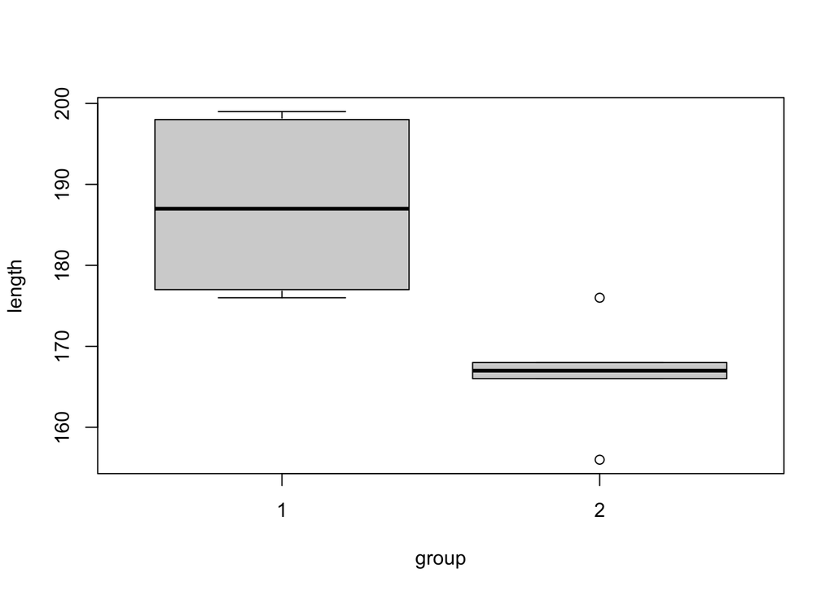

```r
# this is the base-R way to draw a boxplot
boxplot(length~group)
```

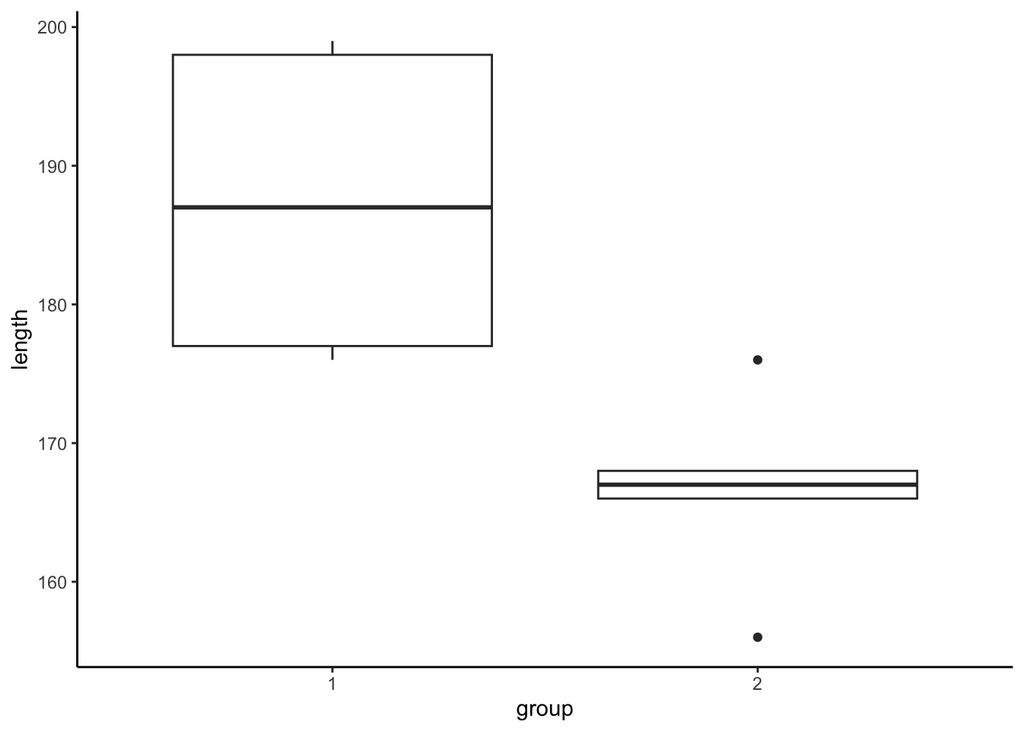

```r
#also with ggplot you can make nice boxplots
inputdata <- tibble(length, group=as.factor(group))
inputdata %>%
    ggplot(aes(x=group, y=length))+
    geom_boxplot()+
    theme_classic()
```

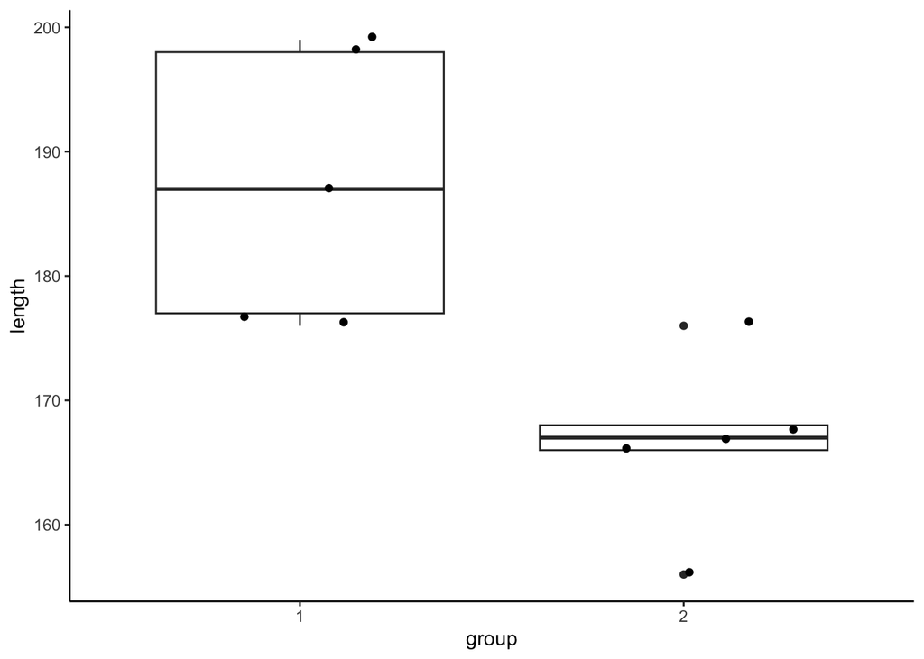

```r
#boxplot with jitter
inputdata <- tibble(length, group=as.factor(group))
inputdata %>%
    ggplot(aes(x=group, y=length))+
    geom_boxplot()+
    theme_classic()+
     geom_jitter()
```

CONCLUSION: As you can see you get exactly the same result. Depending on the format of your data, you chose for one of the 2 approaches.

### 2.1.3 paired t-test

Above examples take into account that the observations are not paired. Go back to situation A (or B) and do a paired analysis. You will perform this type of analysis if for example vector 1 contains the length of 5 children measured in November 2016 while vector 2 contains the lengths **of the same children** (making it paired observations!) measured in November 2014. You can calculate whether these people have significantly grown.

```r
t.test(group1, group2, paired=T) # parametric test
```

```
##
##  Paired t-test
##
## data:  group1 and group2
## t = 2.8533, df = 4, p-value = 0.04624
## alternative hypothesis: true mean difference is not equal to 0
## 95 percent confidence interval:
##   0.560496 41.039504
## sample estimates:
## mean difference
##            20.8
```

```r
wilcox.test(group1, group2, paired=T) # non-parametric test
```

```
##
##  Wilcoxon signed rank exact test
##
## data:  group1 and group2
## V = 15, p-value = 0.0625
## alternative hypothesis: true location shift is not equal to 0
```

CONCLUSION: The persons have significantly grown (p-value < 0.05) in 2 years time (based on a classical t-test), however when we apply a non-parametric Mann-Whitney/Wilcoxon test, the difference is not significant anymore (p > 0.05).

### 2.1.4 exercises on the imported data

#### 2.1.4.1 exercise 1

Is the mean expression of gene39 (MYCN) and gene46 (ODC1) significantly different in the different samples. Sometimes it can be helpful to see the distribution of the genes: can you plot this distribution (make a density plot using geom_density, maybe you can google or ask chatGPT)? Which test would you perform to statistically test the difference in means? Is a non-parametric alternative better? Do you need to approach this in a paired or unpaired way?

```r
#calculate means
expression_data_pergene %>%
    summarise(mean(gene39), mean(gene46))
```

```
## # A tibble: 1 × 2
##   `mean(gene39)` `mean(gene46)`
##            <dbl>          <dbl>
## 1         -0.131        -0.0613
```

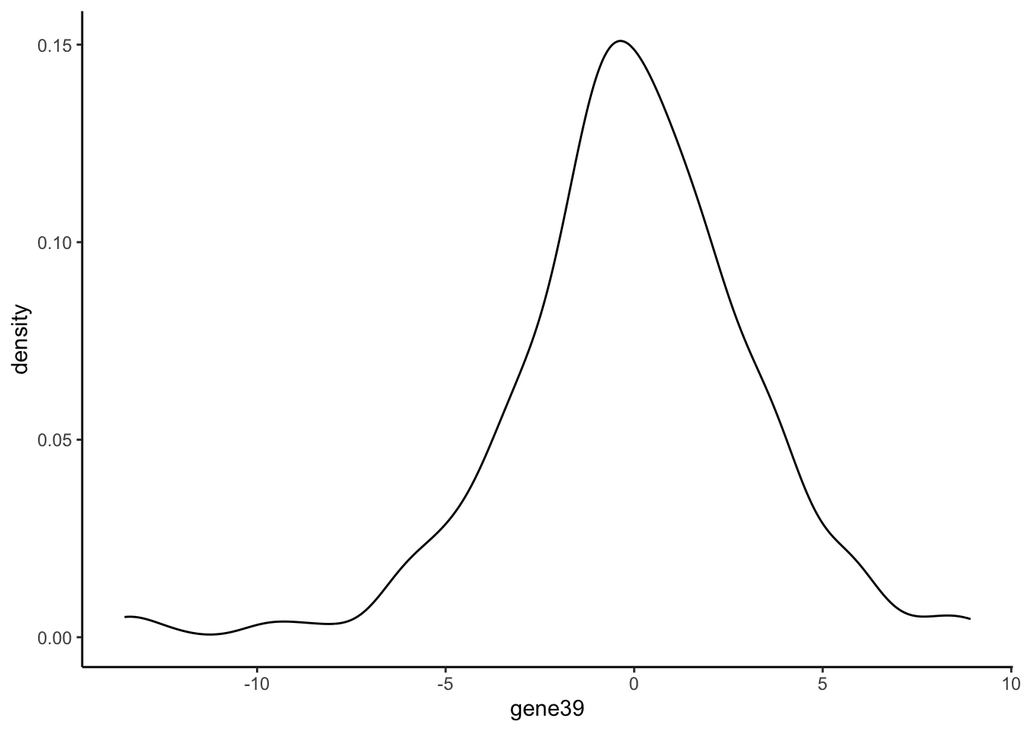

```r
#plot density gene 39
expression_data_pergene %>%
  ggplot(aes(gene39))+
  geom_density()+
  theme_classic()
```

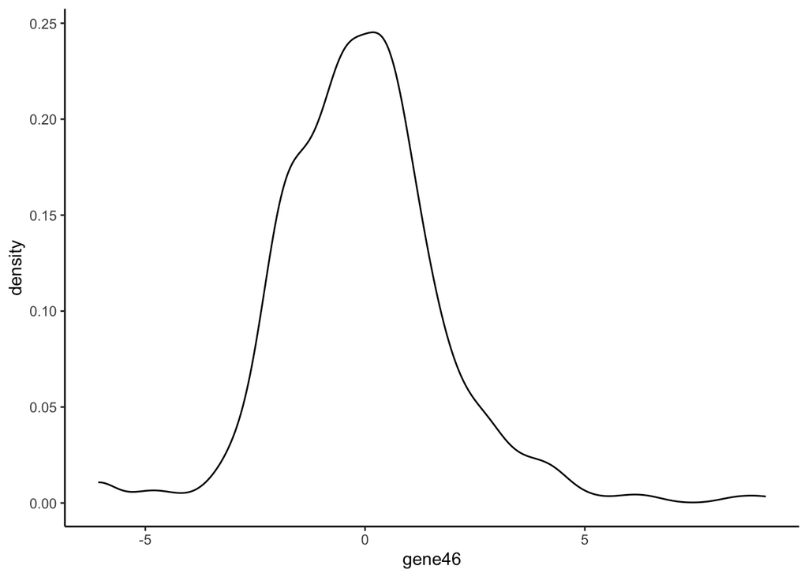

```r
#plot density gene 46
expression_data_pergene %>%
  ggplot(aes(gene46))+
  geom_density()+
  theme_classic()
```

```r
#perform parametric test
t.test(expression_data_pergene$gene39, expression_data_pergene$gene46, paired=T) # a paired test is more interesting to us in this case, as the same samples/patients were tested for gene39 and for gene46 expression.
```

```
##
##  Paired t-test
##
## data:  expression_data_pergene$gene39 and expression_data_pergene$gene46
## t = -0.45132, df = 363, p-value = 0.652
## alternative hypothesis: true mean difference is not equal to 0
## 95 percent confidence interval:
##  -0.3720953  0.2331838
## sample estimates:
## mean difference
##     -0.06945579
```

```r
#perform non-parametric test
wilcox.test(expression_data_pergene$gene39, expression_data_pergene$gene46, paired=T)
```

```
##
##  Wilcoxon signed rank test with continuity correction
##
## data:  expression_data_pergene$gene39 and expression_data_pergene$gene46
## V = 34759, p-value = 0.4423
## alternative hypothesis: true location shift is not equal to 0
```

CONCLUSION: According to both the t-test and the non-parametric Mann-Whitney (Wilcoxon) test their is no significant difference in gene39 versus gene46 expression.

#### 2.1.4.2 exercise 2

Is the expression of gene 14 (CD44) significantly different in samples with MYCN amplification compared to samples without MYCN amplification? Test this also for gene39 (MYCN) and gene 45 (NTKR1). Use a simple t-test as well as a Mann-Whitney test. (In this exercise you will have to use a formula as input with a grouping vector …). Use the boxplot function to visualize the expression of gene 14 in samples with versus without MYCN amplification (in the helpfile of boxplot you can read that you can also use a formula as input).

For this exercise, you have to put expression data (where you can find gene14, gene39 and gene45 expression) and the sample data (where you can find MYCN amplification status) together in one tibble. You can obtain this using the function left_join. This makes sure that the patient order is the same for all variables you’re gonna use in your statistical test. Check this table using the head-function.

```r
all_expression_sample_data <- left_join(expression_data_pergene, sample_data, by=c("name"="patientID"))
head(all_expression_sample_data)
```

```
## # A tibble: 6 × 66
##   name   gene8   gene9  gene10  gene11 gene12 gene13 gene14 gene15  gene16
##   <chr>  <dbl>   <dbl>   <dbl>   <dbl>  <dbl>  <dbl>  <dbl>  <dbl>   <dbl>
## 1 A1    -0.669  0.424  -0.500   0.308  1.50    0.440 -2.18    2.34  0.191
## 2 A10    2.42   3.07    0.0722  3.53   1.14   -4.11   0.637   2.24  2.02
## 3 A11   -1.07  -4.45    0.220   1.64   0.832  -0.670  0.595   5.51 -2.36
## 4 A12    0.883  0.0662  3.41   -1.96   0.0641  0.812  1.18    1.70  4.40
## 5 A13   -1.72  -1.53    1.07   -0.0491 0.854  -0.998 -2.43    4.11 -0.146
## 6 A14   -0.502  1.79   -0.773   1.96   1.84   -0.913  1.06    1.53 -0.0813
## # ℹ 56 more variables: gene17 <dbl>, gene18 <dbl>, gene19 <dbl>, gene21 <dbl>,
## #   gene22 <dbl>, gene23 <dbl>, gene24 <dbl>, gene25 <dbl>, gene26 <dbl>,
## #   gene27 <dbl>, gene28 <dbl>, gene29 <dbl>, gene30 <dbl>, gene31 <dbl>,
## #   gene32 <dbl>, gene33 <dbl>, gene34 <dbl>, gene35 <dbl>, gene36 <dbl>,
## #   gene37 <dbl>, gene38 <dbl>, gene39 <dbl>, gene41 <dbl>, gene43 <dbl>,
## #   gene44 <dbl>, gene45 <dbl>, gene46 <dbl>, gene47 <dbl>, gene48 <dbl>,
## #   gene49 <dbl>, gene50 <dbl>, gene51 <dbl>, gene52 <dbl>, gene53 <dbl>, …
```

Perform the statistical tests and make the boxplots.

```r
# perform parametric tests
t.test(all_expression_sample_data$gene14~all_expression_sample_data$MNA)
```

```
##
##  Welch Two Sample t-test
##
## data:  all_expression_sample_data$gene14 by all_expression_sample_data$MNA
## t = 4.1568, df = 54.992, p-value = 0.0001138
## alternative hypothesis: true difference in means between group 0 and group 1 is not equal to 0
## 95 percent confidence interval:
##  0.8493372 2.4307051
## sample estimates:
## mean in group 0 mean in group 1
##        0.211761       -1.428260
```

```r
t.test(all_expression_sample_data$gene39~all_expression_sample_data$MNA)
```

```
##
##  Welch Two Sample t-test
##
## data:  all_expression_sample_data$gene39 by all_expression_sample_data$MNA
## t = -14.616, df = 76.947, p-value < 2.2e-16
## alternative hypothesis: true difference in means between group 0 and group 1 is not equal to 0
## 95 percent confidence interval:
##  -5.602483 -4.258960
## sample estimates:
## mean in group 0 mean in group 1
##      -0.7674093       4.1633125
```

```r
t.test(all_expression_sample_data$gene45~all_expression_sample_data$MNA)
```

```
##
##  Welch Two Sample t-test
##
## data:  all_expression_sample_data$gene45 by all_expression_sample_data$MNA
## t = 8.0816, df = 52.882, p-value = 8.42e-11
## alternative hypothesis: true difference in means between group 0 and group 1 is not equal to 0
## 95 percent confidence interval:
##  4.536143 7.531271
## sample estimates:
## mean in group 0 mean in group 1
##       0.2751952      -5.7585119
```

```r
# perform non-parametric tests
wilcox.test(all_expression_sample_data$gene14~all_expression_sample_data$MNA)
```

```
##
##  Wilcoxon rank sum test with continuity correction
##
## data:  all_expression_sample_data$gene14 by all_expression_sample_data$MNA
## W = 10217, p-value = 3.951e-05
## alternative hypothesis: true location shift is not equal to 0
```

```r
wilcox.test(all_expression_sample_data$gene39~all_expression_sample_data$MNA)
```

```
##
##  Wilcoxon rank sum test with continuity correction
##
## data:  all_expression_sample_data$gene39 by all_expression_sample_data$MNA
## W = 890, p-value < 2.2e-16
## alternative hypothesis: true location shift is not equal to 0
```

```r
wilcox.test(all_expression_sample_data$gene45~all_expression_sample_data$MNA)
```

```
##
##  Wilcoxon rank sum test with continuity correction
##
## data:  all_expression_sample_data$gene45 by all_expression_sample_data$MNA
## W = 12574, p-value = 2.72e-14
## alternative hypothesis: true location shift is not equal to 0
```

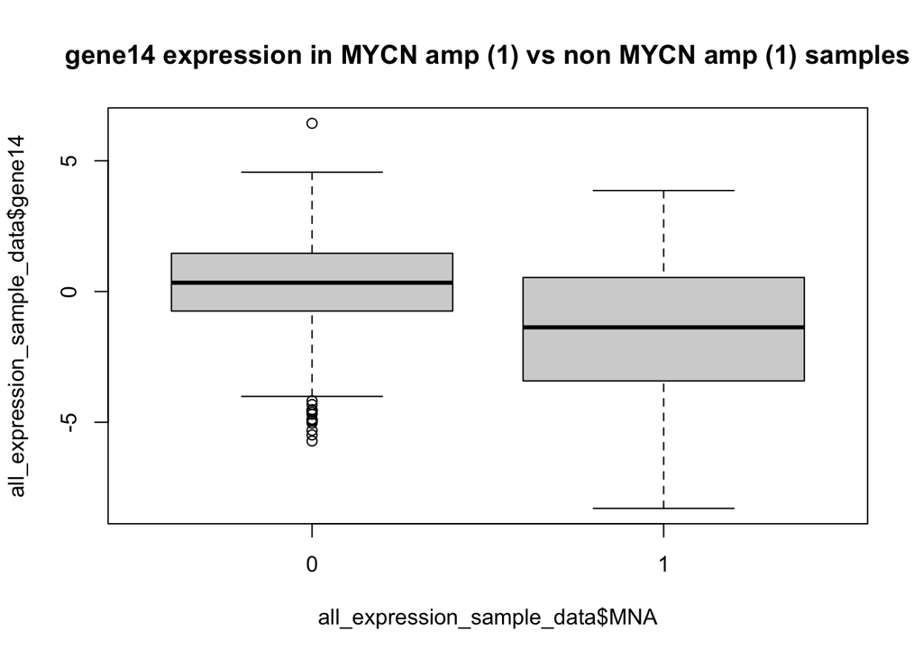

```r
# draw boxplots
boxplot(all_expression_sample_data$gene14~all_expression_sample_data$MNA, main="gene14 expression in MYCN amp (1) vs non MYCN amp (1) samples")
```

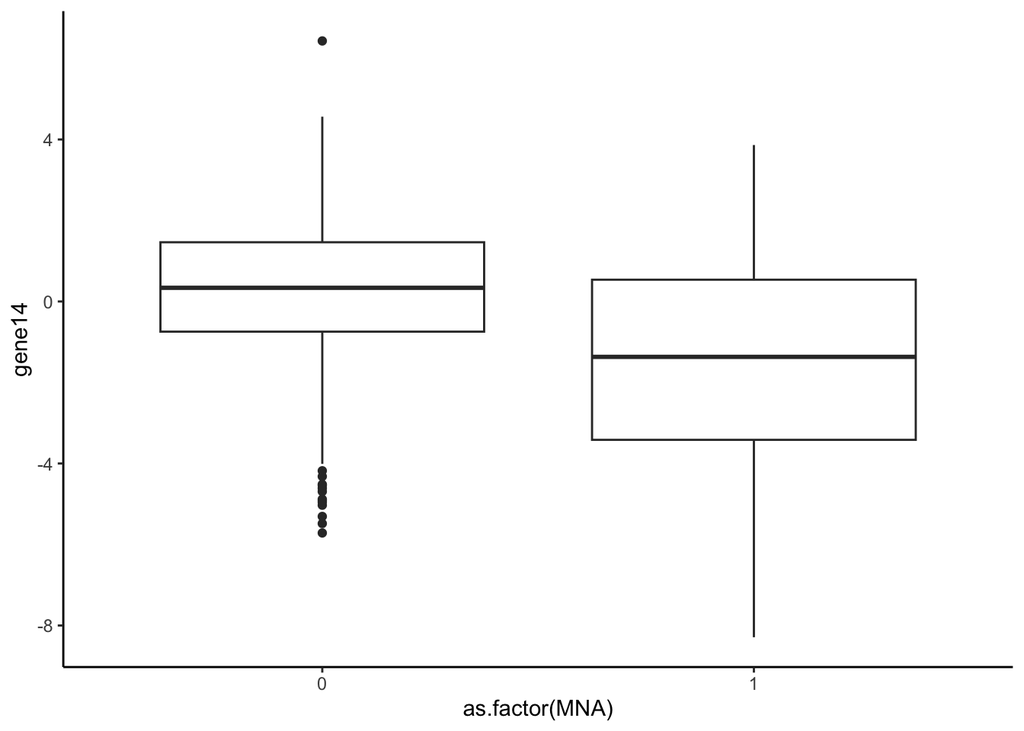

```r
all_expression_sample_data %>%
    ggplot(aes(x=as.factor(MNA), y=gene14))+
    geom_boxplot()+
    theme_classic()
```

CONCLUSION: The expression of the 3 genes is significantly different in samples with versus without MYCN amplification (both in a parametric and non-parametric test) (p < 0.05).

## 2.2 Correlation analysis

Plot expression of both gene 39 and gene 46 in a scatter plot. What is the pearson and spearman correlation coefficient between the expression of both genes and is there a significant correlation? Check the *cor.test()* manual for more information.

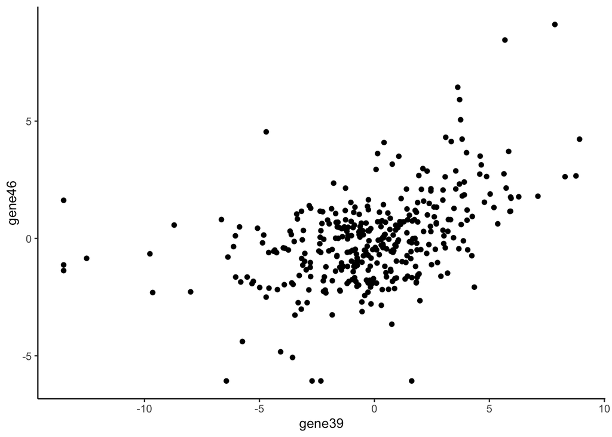

```r
#plot scatter
expression_data_pergene %>%
    ggplot(aes(x=gene39,y=gene46))+
        geom_point()+
        theme_classic()
```

```r
#calculated Pearson and Spearman correlation
cor.test(expression_data_pergene$gene39, expression_data_pergene$gene46) #default: the Pearson correlation will be calculated
```

```
##
##  Pearson's product-moment correlation
##
## data:  expression_data_pergene$gene39 and expression_data_pergene$gene46
## t = 9.5367, df = 362, p-value < 2.2e-16
## alternative hypothesis: true correlation is not equal to 0
## 95 percent confidence interval:
##  0.3619815 0.5266343
## sample estimates:
##       cor
## 0.4480999
```

```r
cor.test(expression_data_pergene$gene39, expression_data_pergene$gene46, method="spearman")
```

```
##
##  Spearman's rank correlation rho
##
## data:  expression_data_pergene$gene39 and expression_data_pergene$gene46
## S = 4493682, p-value < 2.2e-16
## alternative hypothesis: true rho is not equal to 0
## sample estimates:
##       rho
## 0.4409474
```

CONCLUSION: Correlation analysis shows that the expression of these genes are significantly correlated in neuroblastoma samples, which can also be visualized in a scatter plot.

## 2.3 Parametric Anova or non-parametric Kruskal-Wallis test

Look up the help of *anova.lm()* function which will perform an anova test for you. Look to the examples and write a similar script where you test if gene39 differs according to Stage. Print the summary for this. Can you do the same with the non-parametric alternative *kruskal.test()*? And what if we test gene 14 instead? In this way you will learn to interpret help manuals and start working with a new function you have not seen before. Also make a boxplot of the expression of the genes according to stage.

```r
# gene 39
# fit the model
lm_stage_mycn <- lm(gene39 ~ Stage, data=all_expression_sample_data)
# gives you anova test results for the model
anova(lm_stage_mycn)
```

```
## Analysis of Variance Table
##
## Response: gene39
##            Df Sum Sq Mean Sq F value   Pr(>F)
## Stage       4  146.3  36.580  3.5671 0.007197 **
## Residuals 359 3681.5  10.255
## ---
## Signif. codes:  0 '***' 0.001 '**' 0.01 '*' 0.05 '.' 0.1 ' ' 1
```

```r
# gives you results for each value of 'stage'
summary(lm_stage_mycn)
```

```
##
## Call:
## lm(formula = gene39 ~ Stage, data = all_expression_sample_data)
##
## Residuals:
##      Min       1Q   Median       3Q      Max
## -13.0919  -1.4759   0.1241   2.0376   9.3456
##
## Coefficients:
##             Estimate Std. Error t value Pr(>|t|)
## (Intercept)  -0.7345     0.2923  -2.513  0.01242 *
## Stage2        0.6016     0.4907   1.226  0.22101
## Stage3        0.3101     0.5036   0.616  0.53847
## Stage4        1.6865     0.4572   3.689  0.00026 ***
## Stage5        0.6224     0.6221   1.000  0.31780
## ---
## Signif. codes:  0 '***' 0.001 '**' 0.01 '*' 0.05 '.' 0.1 ' ' 1
##
## Residual standard error: 3.202 on 359 degrees of freedom
## Multiple R-squared:  0.03823,    Adjusted R-squared:  0.02751
## F-statistic: 3.567 on 4 and 359 DF,  p-value: 0.007197
```

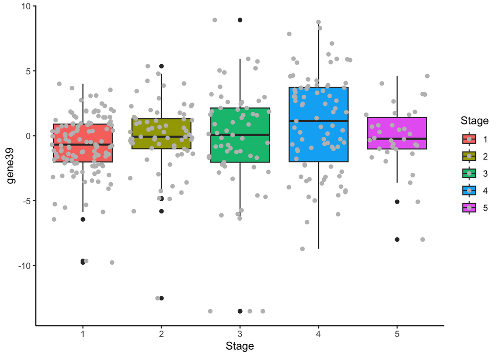

```r
ggplot(all_expression_sample_data, aes(x = Stage, y = gene39, group= Stage, fill=Stage)) +
  geom_boxplot() +
  geom_point(position = "jitter", color="grey")+
  theme_classic()
```

```r
# kruskal wallis test
kruskal.test(gene39 ~ Stage, data=all_expression_sample_data)
```

```
##
##  Kruskal-Wallis rank sum test
##
## data:  gene39 by Stage
## Kruskal-Wallis chi-squared = 13.805, df = 4, p-value = 0.007944
```

```r
#gene 14
# plot the model
lm_stage_mycn <- lm(gene14 ~ Stage, data=all_expression_sample_data)
# gives you anova test results for the model
anova(lm_stage_mycn)
```

```
## Analysis of Variance Table
##
## Response: gene14
##            Df  Sum Sq Mean Sq F value Pr(>F)
## Stage       4   24.77  6.1935  1.2824 0.2764
## Residuals 359 1733.80  4.8295
```

```r
# gives you results for each value of 'stage'
summary(lm_stage_mycn)
```

```
##
## Call:
## lm(formula = gene14 ~ Stage, data = all_expression_sample_data)
##
## Residuals:
##     Min      1Q  Median      3Q     Max
## -7.8817 -1.1892  0.1809  1.4491  6.2760
##
## Coefficients:
##             Estimate Std. Error t value Pr(>|t|)
## (Intercept)  0.08147    0.20061   0.406    0.685
## Stage2      -0.11908    0.33678  -0.354    0.724
## Stage3       0.07497    0.34557   0.217    0.828
## Stage4      -0.48979    0.31374  -1.561    0.119
## Stage5       0.42008    0.42696   0.984    0.326
##
## Residual standard error: 2.198 on 359 degrees of freedom
## Multiple R-squared:  0.01409,    Adjusted R-squared:  0.003102
## F-statistic: 1.282 on 4 and 359 DF,  p-value: 0.2764
```

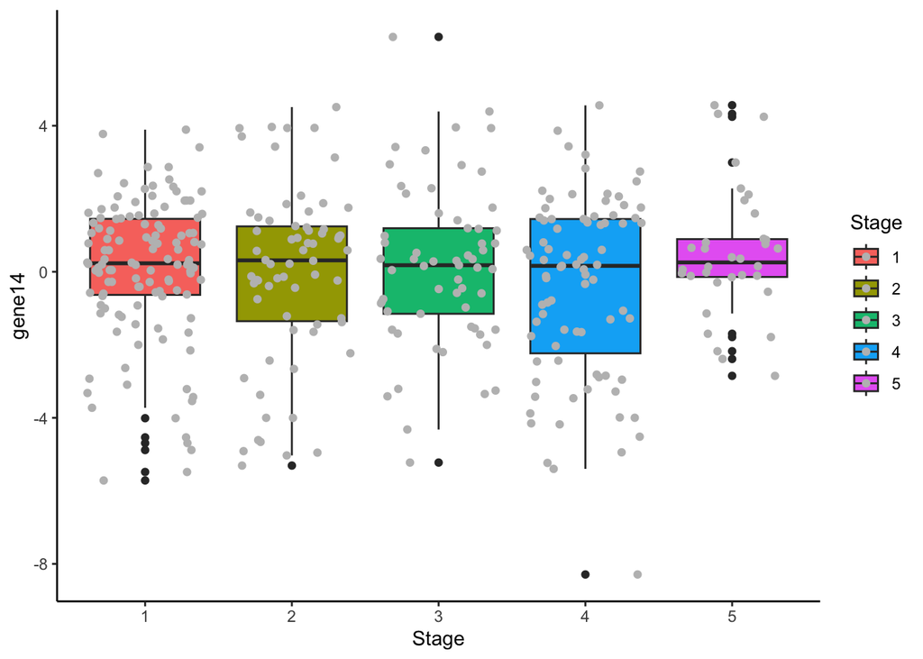

```r
ggplot(all_expression_sample_data, aes(x = Stage, y = gene14, group= Stage, fill=Stage)) +
  geom_boxplot() +
  geom_point(position = "jitter", color="grey")+
  theme_classic()
```

```r
# kruskal wallis test
kruskal.test(gene14 ~ Stage, data=all_expression_sample_data)
```

```
##
##  Kruskal-Wallis rank sum test
##
## data:  gene14 by Stage
## Kruskal-Wallis chi-squared = 1.8683, df = 4, p-value = 0.76
```